# EDA

2022-06-12

```r
colMapping <- read_tsv("~/Dropbox (Dublin Dental Hosp)/iuna-gui/EA-column-remapping - Sheet1.tsv", show_col_types = FALSE)
```

we keep only the column we need by filtering `skip == FALSE`

```r
colMappingKeep <- colMapping %>% filter(skip == FALSE)
```

```r
fileName <- "~/Dropbox (Dublin Dental Hosp)/iuna-gui/Elite_athletes_-_all_versions_-_labels_-_2023-06-01-13-48-49.csv"


rawResponses <- read_csv2(fileName, locale = locale(decimal_mark = ".", grouping_mark = ","), show_col_types = FALSE, name_repair = "minimal")
```

```
## ℹ Using "','" as decimal and "'.'" as grouping mark. Use `read_delim()` for more control.
```

```r
rawSelection <- rawResponses[, colMappingKeep$kobo_header]
colnames(rawSelection) <- colMappingKeep$column_name
```

```r
#rawSelection %>% filter(!participant_id() %in% #c(1,2,3,4,5,6,7))

rawSelection[-c(1,2,3,4,5,6,7),] %>% head()
```

```
## # A tibble: 6 × 177
##   examiner_id participant_id examiner_reproducibi…¹ assessment_date   age gender
##         <dbl> <chr>          <chr>                  <date>          <dbl> <chr>
## 1           1 aa944ab0       Original               2022-06-07         42 Male
## 2           2 2bb7396e       Original               2022-06-07         27 Female
## 3           1 d2b2feb6       Original               2022-06-07         28 Male
## 4           2 dc69b533       Original               2022-06-07         26 Female
## 5           1 0a05931b       Original               2022-06-07         53 Male
## 6           2 79e09e42       Original               2022-06-07         36 Male
## # ℹ abbreviated name: ¹examiner_reproducibility
## # ℹ 171 more variables: gender_details <lgl>, eircode <chr>,
## #   exact_occupation <chr>, occupation <chr>, years_education <dbl>,
## #   level_education <chr>, ethnicity <chr>, other_ethnicity <chr>,
## #   icdas_score_1_18 <dbl>, icdas_score_1_17 <dbl>, icdas_score_1_16 <dbl>,
## #   icdas_score_1_15 <dbl>, icdas_score_1_14 <dbl>, icdas_score_1_13 <dbl>,
## #   icdas_score_1_12 <dbl>, icdas_score_1_11 <dbl>, icdas_score_2_18 <dbl>, …
```

```r
rawSelection2 <- rawSelection[-c(1,2,3,4,5,6,7),]
```

```r
Hmisc::html(Hmisc::describe(rawSelection2))
```

rawSelection2  
177 Variables 88 Observations

examiner_id

| n | missing | distinct | Info | Mean | Gmd |
| --- | --- | --- | --- | --- | --- |
| 88 | 0 | 3 | 0.742 | 97361 | 194719 |

```
 Value            1 8567603
 Frequency       87       1
 Proportion   0.989   0.011
```

For the frequency table, variable is rounded to the nearest 85676.02

participant_id

| n | missing | distinct |
| --- | --- | --- |
| 88 | 0 | 87 |

| lowest : | 0246610f | 046b60e20 | 06455658 | 087c1d44 | 0a05931b |
| --- | --- | --- | --- | --- | --- |
| highest: | f6531cd1 | f81c602e | fbdcfa67 | fe51e362 | fff9d012 |

examiner_reproducibility

| n | missing | distinct | value |
| --- | --- | --- | --- |
| 88 | 0 | 1 | Original |

```
 Value      Original
 Frequency        88
 Proportion        1
```

assessment_date

```
          n    missing   distinct       Info       Mean        Gmd        .05
         88          0         13      0.987 2022-10-23      127.8 2022-06-07
        .10        .25        .50        .75        .90        .95
 2022-06-14 2022-06-21 2022-11-22 2023-02-03 2023-02-13 2023-04-05
```

```
 Value      2022-06-07 2022-06-13 2022-06-19 2022-06-25 2022-07-04 2022-07-10
 Frequency           7         13          4          6          4          2
 Proportion      0.080      0.148      0.045      0.068      0.045      0.023

 Value      2022-08-27 2022-09-05 2022-11-20 2023-01-31 2023-02-12 2023-04-05
 Frequency           2          5          5         20         12          8
 Proportion      0.023      0.057      0.057      0.227      0.136      0.091
```

For the frequency table, variable is rounded to the nearest 3.02

age

| n | missing | distinct | Info | Mean | Gmd | .05 | .10 | .25 | .50 | .75 | .90 | .95 |
| --- | --- | --- | --- | --- | --- | --- | --- | --- | --- | --- | --- | --- |
| 88 | 0 | 20 | 0.993 | 25.61 | 5.812 | 20.00 | 20.00 | 22.00 | 24.50 | 28.00 | 31.30 | 35.65 |

```
 Value      19.00 19.68 20.70 21.72 22.74 23.76 24.78 25.80 26.82 27.84 28.86 29.88
 Frequency      3    12     5    11     7     6     6     7     6     5     4     5
 Proportion 0.034 0.136 0.057 0.125 0.080 0.068 0.068 0.080 0.068 0.057 0.045 0.057

 Value      30.90 31.92 34.98 36.00 37.70 41.78 42.80 53.00
 Frequency      2     3     1     1     1     1     1     1
 Proportion 0.023 0.034 0.011 0.011 0.011 0.011 0.011 0.011
```

For the frequency table, variable is rounded to the nearest 0.34

gender

| n | missing | distinct |
| --- | --- | --- |
| 88 | 0 | 2 |

```
 Value      Female   Male
 Frequency      33     55
 Proportion  0.375  0.625
```

eircode

| n | missing | distinct |
| --- | --- | --- |
| 88 | 0 | 83 |

lowest : A63t665 A84dd51 A85fd72 A91KD68 A91kx38 , highest: T23Y5N8 T56HE16 V93HX64 X91ea3w X91X76V

exact_occupation

| n | missing | distinct |
| --- | --- | --- |
| 88 | 0 | 37 |

| lowest : | Administration | Athlete | Athlete / student | Athlete and student | Athlete/learning and development pwc |
| --- | --- | --- | --- | --- | --- |
| highest: | Tool maker | Unemployed | Working in restaurant | Works as a shop assistant | Works in a bike rental |

occupation

| n | missing | distinct |
| --- | --- | --- |
| 88 | 0 | 4 |

```
 Value      All other gainfully occupied and unknown
 Frequency                                        69
 Proportion                                    0.784

 Value             Other non manual / skilled manual
 Frequency                                         3
 Proportion                                    0.034

 Value                         Professional managers
 Frequency                                         7
 Proportion                                    0.080

 Value               Semi-skilled / unskilled manual
 Frequency                                         9
 Proportion                                    0.102
```

years_education

| n | missing | distinct | Info | Mean | Gmd | .05 | .10 | .25 | .50 | .75 | .90 | .95 |
| --- | --- | --- | --- | --- | --- | --- | --- | --- | --- | --- | --- | --- |
| 88 | 0 | 11 | 0.977 | 16.55 | 2.45 | 13.35 | 14.00 | 15.00 | 17.00 | 18.00 | 19.00 | 20.00 |

```
 Value         11    12    13    14    15    16    17    18    19    20    21
 Frequency      2     1     2    10    17     9    14    18     7     6     2
 Proportion 0.023 0.011 0.023 0.114 0.193 0.102 0.159 0.205 0.080 0.068 0.023
```

For the frequency table, variable is rounded to the nearest 0.1

level_education

| n | missing | distinct |
| --- | --- | --- |
| 88 | 0 | 5 |

FE College (or equivalent) (17, 0.193), Junior Certificate (3, 0.034), Leaving Certificate (26, 0.295), University postgraduate degree (6, 0.068), University undergraduate degree (36, 0.409)

ethnicity

| n | missing | distinct |
| --- | --- | --- |
| 88 | 0 | 7 |

| lowest : | Any other Asian background | Any other white background-please describe | Black or Black Irish | Irish Traveller | Irish White |
| --- | --- | --- | --- | --- | --- |
| highest: | Black or Black Irish | Irish Traveller | Irish White | Northern Irish/English/Welsh/Scotish | Other, including mixed background-please describe |

other_ethnicity

| n | missing | distinct |
| --- | --- | --- |
| 5 | 83 | 5 |

```
 Value                 American             Armenia       South african
 Frequency                    1                   1                   1
 Proportion                 0.2                 0.2                 0.2

 Value            South African Swiss Irish Italian
 Frequency                    1                   1
 Proportion                 0.2                 0.2
```

icdas_score_1_18

| n | missing | distinct | Info | Mean | Gmd |
| --- | --- | --- | --- | --- | --- |
| 88 | 0 | 6 | 0.677 | 30.23 | 42.44 |

```
 Value       0.00  1.98 95.04 96.03 97.02 99.00
 Frequency     60     1     1     1    10    15
 Proportion 0.682 0.011 0.011 0.011 0.114 0.170
```

For the frequency table, variable is rounded to the nearest 0.99

icdas_score_1_17

| n | missing | distinct | Info | Mean | Gmd |
| --- | --- | --- | --- | --- | --- |
| 88 | 0 | 8 | 0.738 | 2.125 | 3.709 |

```
 Value       0.00  0.97  1.94  2.91  3.88  6.79  7.76 97.00
 Frequency     56     9     1    12     7     1     1     1
 Proportion 0.636 0.102 0.011 0.136 0.080 0.011 0.011 0.011
```

For the frequency table, variable is rounded to the nearest 0.97

icdas_score_1_16

| n | missing | distinct | Info | Mean | Gmd |
| --- | --- | --- | --- | --- | --- |
| 88 | 0 | 6 | 0.898 | 1.852 | 1.981 |

```
 Value       0.00  0.98  1.96  2.94  3.99  7.00
 Frequency     37     7     1    24    17     2
 Proportion 0.420 0.080 0.011 0.273 0.193 0.023
```

For the frequency table, variable is rounded to the nearest 0.07

icdas_score_1_15

| n | missing | distinct | Info | Mean | Gmd |
| --- | --- | --- | --- | --- | --- |
| 88 | 0 | 6 | 0.538 | 7.148 | 13.29 |

```
 Value       0.00  0.98  2.94  3.92 96.04 98.00
 Frequency     68     3     5     6     1     5
 Proportion 0.773 0.034 0.057 0.068 0.011 0.057
```

For the frequency table, variable is rounded to the nearest 0.98

icdas_score_1_14

| n | missing | distinct | Info | Mean | Gmd |
| --- | --- | --- | --- | --- | --- |
| 88 | 0 | 8 | 0.405 | 3.773 | 7.259 |

```
 Value       0.00  0.98  1.96  2.94  3.92  5.88  6.86 98.00
 Frequency     74     1     1     6     1     1     1     3
 Proportion 0.841 0.011 0.011 0.068 0.011 0.011 0.011 0.034
```

For the frequency table, variable is rounded to the nearest 0.98

icdas_score_1_13

| n | missing | distinct | Info | Mean | Gmd |
| --- | --- | --- | --- | --- | --- |
| 88 | 0 | 3 | 0.161 | 0.2045 | 0.3934 |

```
 Value          0     3     6
 Frequency     83     4     1
 Proportion 0.943 0.045 0.011
```

For the frequency table, variable is rounded to the nearest 0.06

icdas_score_1_12

| n | missing | distinct | Info | Mean | Gmd |
| --- | --- | --- | --- | --- | --- |
| 88 | 0 | 3 | 0.329 | 1.455 | 2.823 |

```
 Value       0.00  2.94 98.00
 Frequency     77    10     1
 Proportion 0.875 0.114 0.011
```

For the frequency table, variable is rounded to the nearest 0.98

icdas_score_1_11

| n | missing | distinct | Info | Mean | Gmd |
| --- | --- | --- | --- | --- | --- |
| 88 | 0 | 3 | 0.355 | 0.5455 | 0.9781 |

```
 Value          0     3     6
 Frequency     76     8     4
 Proportion 0.864 0.091 0.045
```

For the frequency table, variable is rounded to the nearest 0.06

icdas_score_2_18

| n | missing | distinct | Info | Mean | Gmd |
| --- | --- | --- | --- | --- | --- |
| 88 | 0 | 5 | 0.595 | 0.7727 | 1.225 |

```
 Value          0     2     3     4     5
 Frequency     65     9     8     4     2
 Proportion 0.739 0.102 0.091 0.045 0.023
```

For the frequency table, variable is rounded to the nearest 0.05

icdas_score_2_17

| n | missing | distinct | Info | Mean | Gmd |
| --- | --- | --- | --- | --- | --- |
| 88 | 0 | 7 | 0.895 | 1.636 | 1.817 |

```
 Value       0.00  0.96  1.98  3.00  3.96  4.98  6.00
 Frequency     39     1    19    17     7     4     1
 Proportion 0.443 0.011 0.216 0.193 0.080 0.045 0.011
```

For the frequency table, variable is rounded to the nearest 0.06

icdas_score_2_16

| n | missing | distinct | Info | Mean | Gmd |
| --- | --- | --- | --- | --- | --- |
| 88 | 0 | 5 | 0.89 | 1.625 | 1.7 |

```
 Value          0     2     3     4     5
 Frequency     36    30     9     9     4
 Proportion 0.409 0.341 0.102 0.102 0.045
```

For the frequency table, variable is rounded to the nearest 0.05

icdas_score_2_15

| n | missing | distinct | Info | Mean | Gmd |
| --- | --- | --- | --- | --- | --- |
| 88 | 0 | 4 | 0.428 | 0.4545 | 0.7868 |

```
 Value          0     2     3     4
 Frequency     73     8     4     3
 Proportion 0.830 0.091 0.045 0.034
```

For the frequency table, variable is rounded to the nearest 0.04

icdas_score_2_14

| n | missing | distinct | Info | Mean | Gmd |
| --- | --- | --- | --- | --- | --- |
| 88 | 0 | 5 | 0.452 | 0.625 | 1.08 |

```
 Value       0.00  1.98  3.00  3.96  6.00
 Frequency     72     5     3     6     2
 Proportion 0.818 0.057 0.034 0.068 0.023
```

For the frequency table, variable is rounded to the nearest 0.06

icdas_score_2_13

| n | missing | distinct | Info | Mean | Gmd |
| --- | --- | --- | --- | --- | --- |
| 88 | 0 | 3 | 0.067 | 0.05682 | 0.1126 |

```
 Value       0.00  1.98  3.00
 Frequency     86     1     1
 Proportion 0.977 0.011 0.011
```

For the frequency table, variable is rounded to the nearest 0.03

icdas_score_2_12

| n | missing | distinct | Info | Mean | Gmd |
| --- | --- | --- | --- | --- | --- |
| 88 | 0 | 4 | 0.249 | 0.25 | 0.4671 |

```
 Value          0     2     3     4
 Frequency     80     4     2     2
 Proportion 0.909 0.045 0.023 0.023
```

For the frequency table, variable is rounded to the nearest 0.04

icdas_score_2_11

| n | missing | distinct | Info | Mean | Gmd |
| --- | --- | --- | --- | --- | --- |
| 88 | 0 | 4 | 0.249 | 0.3182 | 0.5909 |

```
 Value          0     2     3     4
 Frequency     80     1     2     5
 Proportion 0.909 0.011 0.023 0.057
```

For the frequency table, variable is rounded to the nearest 0.04

icdas_score_1_21

| n | missing | distinct | Info | Mean | Gmd |
| --- | --- | --- | --- | --- | --- |
| 88 | 0 | 4 | 0.38 | 1.625 | 3.118 |

```
 Value       0.00  2.94  5.88 98.00
 Frequency     75     9     3     1
 Proportion 0.852 0.102 0.034 0.011
```

For the frequency table, variable is rounded to the nearest 0.98

icdas_score_1_22

| n | missing | distinct | Info | Mean | Gmd |
| --- | --- | --- | --- | --- | --- |
| 88 | 0 | 3 | 0.276 | 1.386 | 2.716 |

```
 Value       0.00  2.94 98.00
 Frequency     79     8     1
 Proportion 0.898 0.091 0.011
```

For the frequency table, variable is rounded to the nearest 0.98

icdas_score_1_23

| n | missing | distinct | Info | Mean | Gmd |
| --- | --- | --- | --- | --- | --- |
| 88 | 0 | 3 | 0.13 | 0.1705 | 0.3315 |

```
 Value          0     3     6
 Frequency     84     3     1
 Proportion 0.955 0.034 0.011
```

For the frequency table, variable is rounded to the nearest 0.06

icdas_score_1_24

| n | missing | distinct | Info | Mean | Gmd |
| --- | --- | --- | --- | --- | --- |
| 88 | 0 | 6 | 0.381 | 3.761 | 7.243 |

```
 Value       0.00  1.96  2.94  3.92  5.88 98.00
 Frequency     75     2     3     3     2     3
 Proportion 0.852 0.023 0.034 0.034 0.023 0.034
```

For the frequency table, variable is rounded to the nearest 0.98

icdas_score_1_25

| n | missing | distinct | Info | Mean | Gmd |
| --- | --- | --- | --- | --- | --- |
| 88 | 0 | 6 | 0.538 | 6.295 | 11.71 |

```
 Value       0.00  2.94  3.92  5.88  6.86 98.00
 Frequency     68     4     8     1     2     5
 Proportion 0.773 0.045 0.091 0.011 0.023 0.057
```

For the frequency table, variable is rounded to the nearest 0.98

icdas_score_1_26

| n | missing | distinct | Info | Mean | Gmd |
| --- | --- | --- | --- | --- | --- |
| 88 | 0 | 8 | 0.904 | 1.989 | 2.202 |

```
 Value       0.00  0.96  2.00  2.96  4.00  6.00  6.96  8.00
 Frequency     37     7     2    17    21     1     1     2
 Proportion 0.420 0.080 0.023 0.193 0.239 0.011 0.011 0.023
```

For the frequency table, variable is rounded to the nearest 0.08

icdas_score_1_27

| n | missing | distinct | Info | Mean | Gmd |
| --- | --- | --- | --- | --- | --- |
| 88 | 0 | 6 | 0.696 | 1.068 | 1.634 |

```
 Value       0.00  0.96  2.00  2.96  4.00  8.00
 Frequency     59     5     3     9    10     2
 Proportion 0.670 0.057 0.034 0.102 0.114 0.023
```

For the frequency table, variable is rounded to the nearest 0.08

icdas_score_1_28

| n | missing | distinct | Info | Mean | Gmd |
| --- | --- | --- | --- | --- | --- |
| 88 | 0 | 6 | 0.768 | 35.92 | 46.26 |

```
 Value       0.00  0.99  2.97 95.04 97.02 99.00
 Frequency     53     1     2     1    11    20
 Proportion 0.602 0.011 0.023 0.011 0.125 0.227
```

For the frequency table, variable is rounded to the nearest 0.99

icdas_score_2_21

| n | missing | distinct | Info | Mean | Gmd |
| --- | --- | --- | --- | --- | --- |
| 88 | 0 | 4 | 0.22 | 0.2841 | 0.5332 |

```
 Value          0     2     3     4
 Frequency     81     1     1     5
 Proportion 0.920 0.011 0.011 0.057
```

For the frequency table, variable is rounded to the nearest 0.04

icdas_score_2_22

| n | missing | distinct | Info | Mean | Gmd |
| --- | --- | --- | --- | --- | --- |
| 88 | 0 | 5 | 0.33 | 0.3864 | 0.7006 |

```
 Value          0     1     2     3     4
 Frequency     77     1     2     3     5
 Proportion 0.875 0.011 0.023 0.034 0.057
```

For the frequency table, variable is rounded to the nearest 0.04

icdas_score_2_23

| n | missing | distinct | Info | Mean | Gmd |
| --- | --- | --- | --- | --- | --- |
| 88 | 0 | 2 | 0.067 | 0.04545 | 0.08986 |

```
 Value          0     2
 Frequency     86     2
 Proportion 0.977 0.023
```

icdas_score_2_24

| n | missing | distinct | Info | Mean | Gmd |
| --- | --- | --- | --- | --- | --- |
| 88 | 0 | 4 | 0.428 | 0.4886 | 0.8477 |

```
 Value          0     2     3     4
 Frequency     73     7     3     5
 Proportion 0.830 0.080 0.034 0.057
```

For the frequency table, variable is rounded to the nearest 0.04

icdas_score_2_25

| n | missing | distinct | Info | Mean | Gmd |
| --- | --- | --- | --- | --- | --- |
| 88 | 0 | 5 | 0.474 | 0.6023 | 1.028 |

```
 Value          0     2     3     4     5
 Frequency     71     8     1     6     2
 Proportion 0.807 0.091 0.011 0.068 0.023
```

For the frequency table, variable is rounded to the nearest 0.05

icdas_score_2_26

| n | missing | distinct | Info | Mean | Gmd |
| --- | --- | --- | --- | --- | --- |
| 88 | 0 | 5 | 0.894 | 1.636 | 1.728 |

```
 Value          0     2     3     4     5
 Frequency     38    19    22     5     4
 Proportion 0.432 0.216 0.250 0.057 0.045
```

For the frequency table, variable is rounded to the nearest 0.05

icdas_score_2_27

| n | missing | distinct | Info | Mean | Gmd |
| --- | --- | --- | --- | --- | --- |
| 88 | 0 | 5 | 0.888 | 1.591 | 1.691 |

```
 Value          0     2     3     4     5
 Frequency     39    18    22     7     2
 Proportion 0.443 0.205 0.250 0.080 0.023
```

For the frequency table, variable is rounded to the nearest 0.05

icdas_score_2_28

| n | missing | distinct | Info | Mean | Gmd |
| --- | --- | --- | --- | --- | --- |
| 88 | 0 | 5 | 0.577 | 0.7727 | 1.244 |

```
 Value          0     2     3     4     5
 Frequency     66     8     7     4     3
 Proportion 0.750 0.091 0.080 0.045 0.034
```

For the frequency table, variable is rounded to the nearest 0.05

icdas_score_1_38

| n | missing | distinct | Info | Mean | Gmd |
| --- | --- | --- | --- | --- | --- |
| 88 | 0 | 6 | 0.817 | 38.14 | 47.33 |

```
 Value       0.00  2.97  3.96 95.04 97.02 99.00
 Frequency     49     4     1     5    11    18
 Proportion 0.557 0.045 0.011 0.057 0.125 0.205
```

For the frequency table, variable is rounded to the nearest 0.99

icdas_score_1_37

| n | missing | distinct | Info | Mean | Gmd |
| --- | --- | --- | --- | --- | --- |
| 88 | 0 | 6 | 0.786 | 1.273 | 1.705 |

```
 Value       0.00  0.98  1.96  2.94  3.99  7.00
 Frequency     52     2     7    15    11     1
 Proportion 0.591 0.023 0.080 0.170 0.125 0.011
```

For the frequency table, variable is rounded to the nearest 0.07

icdas_score_1_36

| n | missing | distinct | Info | Mean | Gmd |
| --- | --- | --- | --- | --- | --- |
| 88 | 0 | 7 | 0.897 | 4.875 | 8.066 |

```
 Value       0.00  0.97  1.94  2.91  3.88  7.76 97.00
 Frequency     38     8     3    24    11     1     3
 Proportion 0.432 0.091 0.034 0.273 0.125 0.011 0.034
```

For the frequency table, variable is rounded to the nearest 0.97

icdas_score_1_35

| n | missing | distinct | Info | Mean | Gmd |
| --- | --- | --- | --- | --- | --- |
| 88 | 0 | 7 | 0.356 | 4.852 | 9.276 |

```
 Value       0.00  2.97  3.96  5.94  6.93 97.02 99.00
 Frequency     76     3     3     1     1     3     1
 Proportion 0.864 0.034 0.034 0.011 0.011 0.034 0.011
```

For the frequency table, variable is rounded to the nearest 0.99

icdas_score_1_34

| n | missing | distinct | Info | Mean | Gmd |
| --- | --- | --- | --- | --- | --- |
| 88 | 0 | 2 | 0.099 | 3.341 | 6.528 |

```
 Value          0    98
 Frequency     85     3
 Proportion 0.966 0.034
```

icdas_score_1_33

| n | missing | distinct | Info | Mean | Gmd |
| --- | --- | --- | --- | --- | --- |
| 88 | 0 | 1 | 0 | 0 | 0 |

```
 Value       0
 Frequency  88
 Proportion  1
```

icdas_score_1_32

| n | missing | distinct | Info | Mean | Gmd |
| --- | --- | --- | --- | --- | --- |
| 88 | 0 | 2 | 0.034 | 0.07955 | 0.1591 |

```
 Value          0     7
 Frequency     87     1
 Proportion 0.989 0.011
```

icdas_score_1_31

| n | missing | distinct | Info | Mean | Gmd |
| --- | --- | --- | --- | --- | --- |
| 88 | 0 | 2 | 0.034 | 0.09091 | 0.1818 |

```
 Value          0     8
 Frequency     87     1
 Proportion 0.989 0.011
```

icdas_score_2_38

| n | missing | distinct | Info | Mean | Gmd |
| --- | --- | --- | --- | --- | --- |
| 88 | 0 | 5 | 0.692 | 0.9659 | 1.404 |

```
 Value          0     2     3     4     5
 Frequency     59     9    16     1     3
 Proportion 0.670 0.102 0.182 0.011 0.034
```

For the frequency table, variable is rounded to the nearest 0.05

icdas_score_2_37

| n | missing | distinct | Info | Mean | Gmd |
| --- | --- | --- | --- | --- | --- |
| 88 | 0 | 6 | 0.918 | 1.795 | 1.752 |

```
 Value          0     1     2     3     4     5
 Frequency     33     2    18    24     7     4
 Proportion 0.375 0.023 0.205 0.273 0.080 0.045
```

For the frequency table, variable is rounded to the nearest 0.05

icdas_score_2_36

| n | missing | distinct | Info | Mean | Gmd |
| --- | --- | --- | --- | --- | --- |
| 88 | 0 | 5 | 0.845 | 1.386 | 1.691 |

```
 Value          0     2     3     4     5
 Frequency     46    17    15     7     3
 Proportion 0.523 0.193 0.170 0.080 0.034
```

For the frequency table, variable is rounded to the nearest 0.05

icdas_score_2_35

| n | missing | distinct | Info | Mean | Gmd |
| --- | --- | --- | --- | --- | --- |
| 88 | 0 | 4 | 0.355 | 0.3295 | 0.588 |

```
 Value          0     2     3     4
 Frequency     76     9     1     2
 Proportion 0.864 0.102 0.011 0.023
```

For the frequency table, variable is rounded to the nearest 0.04

icdas_score_2_34

| n | missing | distinct | Info | Mean | Gmd |
| --- | --- | --- | --- | --- | --- |
| 88 | 0 | 4 | 0.249 | 0.2159 | 0.4052 |

```
 Value          0     1     2     4
 Frequency     80     1     5     2
 Proportion 0.909 0.011 0.057 0.023
```

For the frequency table, variable is rounded to the nearest 0.04

icdas_score_2_33

| n | missing | distinct | Info | Mean | Gmd |
| --- | --- | --- | --- | --- | --- |
| 88 | 0 | 2 | 0.161 | 0.1136 | 0.2168 |

```
 Value          0     2
 Frequency     83     5
 Proportion 0.943 0.057
```

icdas_score_2_32

| n | missing | distinct | Info | Mean | Gmd |
| --- | --- | --- | --- | --- | --- |
| 88 | 0 | 2 | 0.067 | 0.04545 | 0.08986 |

```
 Value          0     2
 Frequency     86     2
 Proportion 0.977 0.023
```

icdas_score_2_31

| n | missing | distinct | Info | Mean | Gmd |
| --- | --- | --- | --- | --- | --- |
| 88 | 0 | 2 | 0.099 | 0.06818 | 0.1332 |

```
 Value          0     2
 Frequency     85     3
 Proportion 0.966 0.034
```

icdas_score_1_41

| n | missing | distinct | Info | Mean | Gmd |
| --- | --- | --- | --- | --- | --- |
| 88 | 0 | 2 | 0.034 | 0.03409 | 0.06818 |

```
 Value          0     3
 Frequency     87     1
 Proportion 0.989 0.011
```

icdas_score_1_42

| n | missing | distinct | Info | Mean | Gmd |
| --- | --- | --- | --- | --- | --- |
| 88 | 0 | 3 | 0.067 | 1.148 | 2.294 |

```
 Value       0.00  2.94 98.00
 Frequency     86     1     1
 Proportion 0.977 0.011 0.011
```

For the frequency table, variable is rounded to the nearest 0.98

icdas_score_1_43

| n | missing | distinct | Info | Mean | Gmd |
| --- | --- | --- | --- | --- | --- |
| 88 | 0 | 2 | 0.034 | 0.03409 | 0.06818 |

```
 Value          0     3
 Frequency     87     1
 Proportion 0.989 0.011
```

icdas_score_1_44

| n | missing | distinct | Info | Mean | Gmd |
| --- | --- | --- | --- | --- | --- |
| 88 | 0 | 4 | 0.161 | 3.398 | 6.633 |

```
 Value       0.00  0.98  3.92 98.00
 Frequency     83     1     1     3
 Proportion 0.943 0.011 0.011 0.034
```

For the frequency table, variable is rounded to the nearest 0.98

icdas_score_1_45

| n | missing | distinct | Info | Mean | Gmd |
| --- | --- | --- | --- | --- | --- |
| 88 | 0 | 5 | 0.22 | 4.602 | 8.868 |

```
 Value       0.00  2.97  5.94 97.02 99.00
 Frequency     81     2     1     3     1
 Proportion 0.920 0.023 0.011 0.034 0.011
```

For the frequency table, variable is rounded to the nearest 0.99

icdas_score_1_46

| n | missing | distinct | Info | Mean | Gmd |
| --- | --- | --- | --- | --- | --- |
| 88 | 0 | 8 | 0.878 | 8.182 | 14.22 |

```
 Value       0.00  0.97  1.94  2.91  3.88  6.79  7.76 97.00
 Frequency     43     7     3    14     8     5     2     6
 Proportion 0.489 0.080 0.034 0.159 0.091 0.057 0.023 0.068
```

For the frequency table, variable is rounded to the nearest 0.97

icdas_score_1_47

| n | missing | distinct | Info | Mean | Gmd |
| --- | --- | --- | --- | --- | --- |
| 88 | 0 | 7 | 0.809 | 3.364 | 5.853 |

```
 Value       0.00  0.97  1.94  2.91  3.88  6.79 97.00
 Frequency     50     7     4    16     8     1     2
 Proportion 0.568 0.080 0.045 0.182 0.091 0.011 0.023
```

For the frequency table, variable is rounded to the nearest 0.97

icdas_score_1_48

| n | missing | distinct | Info | Mean | Gmd |
| --- | --- | --- | --- | --- | --- |
| 88 | 0 | 7 | 0.8 | 37.1 | 46.88 |

```
 Value       0.00  0.99  2.97  3.96 95.04 97.02 99.00
 Frequency     50     1     2     2     3     8    22
 Proportion 0.568 0.011 0.023 0.023 0.034 0.091 0.250
```

For the frequency table, variable is rounded to the nearest 0.99

icdas_score_2_41

| n | missing | distinct | Info | Mean | Gmd |
| --- | --- | --- | --- | --- | --- |
| 88 | 0 | 2 | 0.067 | 0.04545 | 0.08986 |

```
 Value          0     2
 Frequency     86     2
 Proportion 0.977 0.023
```

icdas_score_2_42

| n | missing | distinct | Info | Mean | Gmd |
| --- | --- | --- | --- | --- | --- |
| 88 | 0 | 2 | 0.034 | 0.02273 | 0.04545 |

```
 Value          0     2
 Frequency     87     1
 Proportion 0.989 0.011
```

icdas_score_2_43

| n | missing | distinct | Info | Mean | Gmd |
| --- | --- | --- | --- | --- | --- |
| 88 | 0 | 2 | 0.161 | 0.1136 | 0.2168 |

```
 Value          0     2
 Frequency     83     5
 Proportion 0.943 0.057
```

icdas_score_2_44

| n | missing | distinct | Info | Mean | Gmd |
| --- | --- | --- | --- | --- | --- |
| 88 | 0 | 5 | 0.276 | 0.2273 | 0.4206 |

```
 Value          0     1     2     3     4
 Frequency     79     1     6     1     1
 Proportion 0.898 0.011 0.068 0.011 0.011
```

For the frequency table, variable is rounded to the nearest 0.04

icdas_score_2_45

| n | missing | distinct | Info | Mean | Gmd |
| --- | --- | --- | --- | --- | --- |
| 88 | 0 | 6 | 0.451 | 0.4773 | 0.8276 |

```
 Value       0.00  0.96  1.98  3.00  3.96  6.00
 Frequency     72     1     9     3     2     1
 Proportion 0.818 0.011 0.102 0.034 0.023 0.011
```

For the frequency table, variable is rounded to the nearest 0.06

icdas_score_2_46

| n | missing | distinct | Info | Mean | Gmd |
| --- | --- | --- | --- | --- | --- |
| 88 | 0 | 5 | 0.838 | 1.409 | 1.765 |

```
 Value          0     2     3     4     5
 Frequency     47    16    13     7     5
 Proportion 0.534 0.182 0.148 0.080 0.057
```

For the frequency table, variable is rounded to the nearest 0.05

icdas_score_2_47

| n | missing | distinct | Info | Mean | Gmd |
| --- | --- | --- | --- | --- | --- |
| 88 | 0 | 6 | 0.843 | 1.318 | 1.611 |

```
 Value          0     1     2     3     4     5
 Frequency     46     1    18    15     6     2
 Proportion 0.523 0.011 0.205 0.170 0.068 0.023
```

For the frequency table, variable is rounded to the nearest 0.05

icdas_score_2_48

| n | missing | distinct | Info | Mean | Gmd |
| --- | --- | --- | --- | --- | --- |
| 88 | 0 | 5 | 0.693 | 0.9091 | 1.32 |

```
 Value          0     2     3     4     5
 Frequency     59    12    13     3     1
 Proportion 0.670 0.136 0.148 0.034 0.011
```

For the frequency table, variable is rounded to the nearest 0.05

BEWE_UR

| n | missing | distinct |
| --- | --- | --- |
| 88 | 0 | 3 |

BEWE_UA

| n | missing | distinct |
| --- | --- | --- |
| 88 | 0 | 3 |

BEWE_UL

| n | missing | distinct |
| --- | --- | --- |
| 88 | 0 | 3 |

BEWE_LR

| n | missing | distinct |
| --- | --- | --- |
| 88 | 0 | 3 |

BEWE_LA

| n | missing | distinct |
| --- | --- | --- |
| 88 | 0 | 3 |

BEWE_LL

| n | missing | distinct |
| --- | --- | --- |
| 88 | 0 | 3 |

BPE_UR

| n | missing | distinct |
| --- | --- | --- |
| 88 | 0 | 3 |

BPE_UA

| n | missing | distinct |
| --- | --- | --- |
| 88 | 0 | 3 |

BPE_UL

| n | missing | distinct |
| --- | --- | --- |
| 88 | 0 | 3 |

BPE_LR

| n | missing | distinct |
| --- | --- | --- |
| 88 | 0 | 3 |

BPE_LA

| n | missing | distinct |
| --- | --- | --- |
| 88 | 0 | 3 |

BPE_LL

| n | missing | distinct |
| --- | --- | --- |
| 88 | 0 | 3 |

trauma_status

| n | missing | distinct |
| --- | --- | --- |
| 88 | 0 | 7 |

Enamel and dentine fracture (10, 0.114), Enamel fracture only (18, 0.205), Missing tooth due to trauma (3, 0.034), No sign of injury (49, 0.557), Other damage (3, 0.034), Pulp involvement (4, 0.045), Treated injury (1, 0.011)

trauma_number_teeth

| n | missing | distinct | Info | Mean | Gmd |
| --- | --- | --- | --- | --- | --- |
| 88 | 0 | 6 | 0.803 | 0.6932 | 0.948 |

```
 Value       0.00  0.96  1.98  3.00  3.96  6.00
 Frequency     49    25    10     2     1     1
 Proportion 0.557 0.284 0.114 0.023 0.011 0.011
```

For the frequency table, variable is rounded to the nearest 0.06

PUFA_p

| n | missing | distinct | value |
| --- | --- | --- | --- |
| 88 | 0 | 1 | no lesions |

```
 Value      no lesions
 Frequency          88
 Proportion          1
```

PUFA_u

| n | missing | distinct | value |
| --- | --- | --- | --- |
| 88 | 0 | 1 | no lesions |

```
 Value      no lesions
 Frequency          88
 Proportion          1
```

PUFA_f

| n | missing | distinct | value |
| --- | --- | --- | --- |
| 88 | 0 | 1 | no lesions |

```
 Value      no lesions
 Frequency          88
 Proportion          1
```

PUFA_a

| n | missing | distinct | value |
| --- | --- | --- | --- |
| 88 | 0 | 1 | no lesions |

```
 Value      no lesions
 Frequency          88
 Proportion          1
```

8s_pain

| n | missing | distinct |
| --- | --- | --- |
| 88 | 0 | 2 |

```
 Value         No   Yes
 Frequency     74    14
 Proportion 0.841 0.159
```

8s_ infection

| n | missing | distinct |
| --- | --- | --- |
| 88 | 0 | 2 |

```
 Value         No   Yes
 Frequency     74    14
 Proportion 0.841 0.159
```

TMJ_pain

| n | missing | distinct |
| --- | --- | --- |
| 88 | 0 | 2 |

```
 Value         No   Yes
 Frequency     79     9
 Proportion 0.898 0.102
```

TMJ_trismus

| n | missing | distinct |
| --- | --- | --- |
| 88 | 0 | 2 |

```
 Value         No   Yes
 Frequency     79     9
 Proportion 0.898 0.102
```

sport

| n | missing | distinct |
| --- | --- | --- |
| 88 | 0 | 4 |

```
 Value        Boxing    Other   Rowing Swimming
 Frequency        22       40       21        5
 Proportion    0.250    0.455    0.239    0.057
```

sport_details

| n | missing | distinct |
| --- | --- | --- |
| 40 | 48 | 8 |

| lowest : | Cricket | Cricketer | Cycling endurance | Gymnastics | Para cycling |
| --- | --- | --- | --- | --- | --- |
| highest: | Gymnastics | Para cycling | Para Cycling | Para cycling - tandem pilot | Triathlete |

duration_elite

| n | missing | distinct | Info | Mean | Gmd | .05 | .10 | .25 | .50 | .75 | .90 | .95 |
| --- | --- | --- | --- | --- | --- | --- | --- | --- | --- | --- | --- | --- |
| 88 | 0 | 15 | 0.989 | 5.58 | 4.035 | 1.0 | 1.0 | 3.0 | 5.0 | 8.0 | 11.3 | 12.0 |

```
 Value       1.00  1.98  2.96  3.94  4.92  5.90  6.88  8.00  8.98  9.96 10.94 11.92
 Frequency     10     8    11    12    11    10     3     5     1     6     2     5
 Proportion 0.114 0.091 0.125 0.136 0.125 0.114 0.034 0.057 0.011 0.068 0.023 0.057

 Value      12.90 13.88 15.00
 Frequency      1     1     2
 Proportion 0.011 0.011 0.023
```

For the frequency table, variable is rounded to the nearest 0.14

describe_health

| n | missing | distinct |
| --- | --- | --- |
| 88 | 0 | 4 |

```
 Value           Fair      Good      Poor Very good
 Frequency          2        31         1        54
 Proportion     0.023     0.352     0.011     0.614
```

describe_oralhealth

| n | missing | distinct |
| --- | --- | --- |
| 88 | 0 | 4 |

```
 Value           Fair      Good      Poor Very good
 Frequency         21        45         8        14
 Proportion     0.239     0.511     0.091     0.159
```

teeth_affect_eating

| n | missing | distinct |
| --- | --- | --- |
| 88 | 0 | 5 |

```
 Value      A fair amount  A great deal      A little    Not at all      Somewhat
 Frequency              6             2            12            63             5
 Proportion         0.068         0.023         0.136         0.716         0.057
```

teeth_affect_relaxing

| n | missing | distinct |
| --- | --- | --- |
| 88 | 0 | 5 |

```
 Value      A fair amount  A great deal      A little    Not at all      Somewhat
 Frequency              2             2             4            76             4
 Proportion         0.023         0.023         0.045         0.864         0.045
```

teeth_affect_smiling

| n | missing | distinct |
| --- | --- | --- |
| 88 | 0 | 3 |

```
 Value      A fair amount      A little    Not at all
 Frequency              3             6            79
 Proportion         0.034         0.068         0.898
```

teeth_affect_participation

| n | missing | distinct |
| --- | --- | --- |
| 88 | 0 | 5 |

```
 Value      A fair amount  A great deal      A little    Not at all      Somewhat
 Frequency              1             1             3            81             2
 Proportion         0.011         0.011         0.034         0.920         0.023
```

reduction_training

| n | missing | distinct |
| --- | --- | --- |
| 88 | 0 | 5 |

Could not participate at all (1, 0.011), Major reduction (1, 0.011), Minor reduction (6, 0.068), Moderate reduction (1, 0.011), No reduction (79, 0.898)

reduction_competition

| n | missing | distinct |
| --- | --- | --- |
| 88 | 0 | 2 |

```
 Value      Minor reduction    No reduction
 Frequency                2              86
 Proportion           0.023           0.977
```

reduction_performance

| n | missing | distinct |
| --- | --- | --- |
| 88 | 0 | 3 |

```
 Value         Minor reduction Moderate reduction       No reduction
 Frequency                   2                  3                 83
 Proportion              0.023              0.034              0.943
```

pain_12months

| n | missing | distinct |
| --- | --- | --- |
| 88 | 0 | 4 |

```
 Value          Mild pain Moderate pain       No pain   Severe pain
 Frequency             20            10            53             5
 Proportion         0.227         0.114         0.602         0.057
```

tobacco

| n | missing | distinct |
| --- | --- | --- |
| 88 | 0 | 3 |

```
 Value       Current use    Never use Previous use
 Frequency             1           79            8
 Proportion        0.011        0.898        0.091
```

smokeless_tobacco

| n | missing | distinct |
| --- | --- | --- |
| 88 | 0 | 2 |

```
 Value         Never use Previous use
 Frequency            87            1
 Proportion        0.989        0.011
```

ecig_nicotine

| n | missing | distinct |
| --- | --- | --- |
| 88 | 0 | 3 |

```
 Value       Current use    Never use Previous use
 Frequency             5           79            4
 Proportion        0.057        0.898        0.045
```

ecig_without_nicotine

| n | missing | distinct |
| --- | --- | --- |
| 88 | 0 | 2 |

```
 Value         Never use Previous use
 Frequency            87            1
 Proportion        0.989        0.011
```

frequency_cakes

| n | missing | distinct |
| --- | --- | --- |
| 88 | 0 | 5 |

```
 Value         1-2 times per week    3-5 times per week     6+ times per week
 Frequency                     38                    16                     7
 Proportion                 0.432                 0.182                 0.080

 Value      Less than once a week       Rarely or never
 Frequency                     13                    14
 Proportion                 0.148                 0.159
```

frequency_sweets

| n | missing | distinct |
| --- | --- | --- |
| 88 | 0 | 5 |

```
 Value         1-2 times per week    3-5 times per week     6+ times per week
 Frequency                     28                    27                    19
 Proportion                 0.318                 0.307                 0.216

 Value      Less than once a week       Rarely or never
 Frequency                     10                     4
 Proportion                 0.114                 0.045
```

frequency_nondiet_drinks

| n | missing | distinct |
| --- | --- | --- |
| 88 | 0 | 5 |

```
 Value         1-2 times per week    3-5 times per week     6+ times per week
 Frequency                     16                    10                     9
 Proportion                 0.182                 0.114                 0.102

 Value      Less than once a week       Rarely or never
 Frequency                     11                    42
 Proportion                 0.125                 0.477
```

frequency_diet_drinks

| n | missing | distinct |
| --- | --- | --- |
| 88 | 0 | 5 |

```
 Value         1-2 times per week    3-5 times per week     6+ times per week
 Frequency                     22                    13                     8
 Proportion                 0.250                 0.148                 0.091

 Value      Less than once a week       Rarely or never
 Frequency                     14                    31
 Proportion                 0.159                 0.352
```

bars_before_training

| n | missing | distinct |
| --- | --- | --- |
| 88 | 0 | 3 |

```
 Value         Always     Never Sometimes
 Frequency          4        60        24
 Proportion     0.045     0.682     0.273
```

bars_during_training

| n | missing | distinct |
| --- | --- | --- |
| 88 | 0 | 3 |

```
 Value         Always     Never Sometimes
 Frequency          7        73         8
 Proportion     0.080     0.830     0.091
```

bars_after_training

| n | missing | distinct |
| --- | --- | --- |
| 88 | 0 | 3 |

```
 Value         Always     Never Sometimes
 Frequency         11        47        30
 Proportion     0.125     0.534     0.341
```

bars_before_competition

| n | missing | distinct |
| --- | --- | --- |
| 88 | 0 | 3 |

```
 Value         Always     Never Sometimes
 Frequency          5        63        20
 Proportion     0.057     0.716     0.227
```

bars_during_competition

| n | missing | distinct |
| --- | --- | --- |
| 88 | 0 | 3 |

```
 Value         Always     Never Sometimes
 Frequency          6        72        10
 Proportion     0.068     0.818     0.114
```

bars_after_competition

| n | missing | distinct |
| --- | --- | --- |
| 88 | 0 | 3 |

```
 Value         Always     Never Sometimes
 Frequency         10        60        18
 Proportion     0.114     0.682     0.205
```

brand_bar

| n | missing | distinct |
| --- | --- | --- |
| 88 | 0 | 44 |

| lowest : | Barbells protein bar | Fulfil nature valley | Fulfill | Fulfill protein | Full fill |
| --- | --- | --- | --- | --- | --- |
| highest: | Protein, Kinetica | Sis | Sis kinetica | Snickers, mars | Sponsor |

gels_before_training

| n | missing | distinct |
| --- | --- | --- |
| 88 | 0 | 3 |

```
 Value         Always     Never Sometimes
 Frequency          4        60        24
 Proportion     0.045     0.682     0.273
```

gels_during_training

| n | missing | distinct |
| --- | --- | --- |
| 88 | 0 | 3 |

```
 Value         Always     Never Sometimes
 Frequency          7        73         8
 Proportion     0.080     0.830     0.091
```

gels_after_training

| n | missing | distinct |
| --- | --- | --- |
| 88 | 0 | 3 |

```
 Value         Always     Never Sometimes
 Frequency         11        47        30
 Proportion     0.125     0.534     0.341
```

gels_before_competition

| n | missing | distinct |
| --- | --- | --- |
| 88 | 0 | 3 |

```
 Value         Always     Never Sometimes
 Frequency          5        63        20
 Proportion     0.057     0.716     0.227
```

gels_during_competition

| n | missing | distinct |
| --- | --- | --- |
| 88 | 0 | 3 |

```
 Value         Always     Never Sometimes
 Frequency          6        72        10
 Proportion     0.068     0.818     0.114
```

gels_after_competition

| n | missing | distinct |
| --- | --- | --- |
| 88 | 0 | 3 |

```
 Value         Always     Never Sometimes
 Frequency         10        60        18
 Proportion     0.114     0.682     0.205
```

brand_gels

| n | missing | distinct |
| --- | --- | --- |
| 88 | 0 | 10 |

```
 Value             Kinetica Kinetica or SIS    Kinetica sis    Kinetica SIS
 Frequency               23               1               1               1
 Proportion           0.261           0.011           0.011           0.011

 Value         Kinetica/SIS        Kinetika             N/a              Na
 Frequency                1              11               3              39
 Proportion           0.011           0.125           0.034           0.443

 Value                  Nil             Sis
 Frequency                7               1
 Proportion           0.080           0.011
```

drinks_before_training

| n | missing | distinct |
| --- | --- | --- |
| 88 | 0 | 3 |

```
 Value         Always     Never Sometimes
 Frequency          4        60        24
 Proportion     0.045     0.682     0.273
```

drinks_during_training

| n | missing | distinct |
| --- | --- | --- |
| 88 | 0 | 3 |

```
 Value         Always     Never Sometimes
 Frequency          7        73         8
 Proportion     0.080     0.830     0.091
```

drinks_after_training

| n | missing | distinct |
| --- | --- | --- |
| 88 | 0 | 3 |

```
 Value         Always     Never Sometimes
 Frequency         11        47        30
 Proportion     0.125     0.534     0.341
```

drinks_before_competitions

| n | missing | distinct |
| --- | --- | --- |
| 88 | 0 | 3 |

```
 Value         Always     Never Sometimes
 Frequency          5        63        20
 Proportion     0.057     0.716     0.227
```

drinks_during_competitions

| n | missing | distinct |
| --- | --- | --- |
| 88 | 0 | 3 |

```
 Value         Always     Never Sometimes
 Frequency          6        72        10
 Proportion     0.068     0.818     0.114
```

drinks_after_competitions

| n | missing | distinct |
| --- | --- | --- |
| 88 | 0 | 3 |

```
 Value         Always     Never Sometimes
 Frequency         10        60        18
 Proportion     0.114     0.682     0.205
```

brand_drinks

| n | missing | distinct |
| --- | --- | --- |
| 88 | 0 | 47 |

| lowest : | Dilute juice (miwadi) and salt or Powerade | Electrolyte drinks kinetica | Electrolyte Kinetica | Electrolyte Kinetica tabs | Electrolyte tabs kinetica |
| --- | --- | --- | --- | --- | --- |
| highest: | Sis hydration | Sis recovery electrolytes | Sis recovery or hydration | Sugar in water | Tablets |

damage_cakes

| n | missing | distinct |
| --- | --- | --- |
| 88 | 0 | 3 |

```
 Value      Don't know         No        Yes
 Frequency           5          4         79
 Proportion      0.057      0.045      0.898
```

damage_sweets

| n | missing | distinct | value |
| --- | --- | --- | --- |
| 88 | 0 | 1 | Yes |

```
 Value      Yes
 Frequency   88
 Proportion   1
```

damage_fizzy_drinks

| n | missing | distinct | value |
| --- | --- | --- | --- |
| 88 | 0 | 1 | Yes |

```
 Value      Yes
 Frequency   88
 Proportion   1
```

damage_sports_drinks

| n | missing | distinct |
| --- | --- | --- |
| 88 | 0 | 3 |

```
 Value      Don't know         No        Yes
 Frequency           1          1         86
 Proportion      0.011      0.011      0.977
```

damage_bars

| n | missing | distinct |
| --- | --- | --- |
| 88 | 0 | 3 |

```
 Value      Don't know         No        Yes
 Frequency           9          8         71
 Proportion      0.102      0.091      0.807
```

damage_gels

| n | missing | distinct |
| --- | --- | --- |
| 88 | 0 | 3 |

```
 Value      Don't know         No        Yes
 Frequency           8          5         75
 Proportion      0.091      0.057      0.852
```

damage_smoking_tobacco

| n | missing | distinct |
| --- | --- | --- |
| 88 | 0 | 2 |

```
 Value      Don't know        Yes
 Frequency           1         87
 Proportion      0.011      0.989
```

damage_smokeless_tobacco

| n | missing | distinct |
| --- | --- | --- |
| 88 | 0 | 3 |

```
 Value      Don't know         No        Yes
 Frequency           8          1         79
 Proportion      0.091      0.011      0.898
```

damage_ecig_nicotine

| n | missing | distinct |
| --- | --- | --- |
| 88 | 0 | 3 |

```
 Value      Don't know         No        Yes
 Frequency          15          3         70
 Proportion      0.170      0.034      0.795
```

damage_ecig_without_nicotine

| n | missing | distinct |
| --- | --- | --- |
| 88 | 0 | 3 |

```
 Value      Don't know         No        Yes
 Frequency          19          4         65
 Proportion      0.216      0.045      0.739
```

advice_teeth

| n | missing | distinct |
| --- | --- | --- |
| 88 | 0 | 2 |

```
 Value         No   Yes
 Frequency      8    80
 Proportion 0.091 0.909
```

advice_diet

| n | missing | distinct |
| --- | --- | --- |
| 88 | 0 | 2 |

```
 Value        No  Yes
 Frequency    29   59
 Proportion 0.33 0.67
```

clean_morning

| n | missing | distinct |
| --- | --- | --- |
| 88 | 0 | 2 |

```
 Value         No   Yes
 Frequency      3    85
 Proportion 0.034 0.966
```

clean_night

| n | missing | distinct |
| --- | --- | --- |
| 88 | 0 | 2 |

```
 Value         No   Yes
 Frequency      3    85
 Proportion 0.034 0.966
```

clean_before_nap

| n | missing | distinct |
| --- | --- | --- |
| 88 | 0 | 2 |

```
 Value         No   Yes
 Frequency     85     3
 Proportion 0.966 0.034
```

clean_after_nap

| n | missing | distinct |
| --- | --- | --- |
| 88 | 0 | 2 |

```
 Value         No   Yes
 Frequency     74    14
 Proportion 0.841 0.159
```

clean_other

| n | missing | distinct |
| --- | --- | --- |
| 88 | 0 | 2 |

```
 Value        No  Yes
 Frequency    73   15
 Proportion 0.83 0.17
```

manual_tb

| n | missing | distinct |
| --- | --- | --- |
| 88 | 0 | 2 |

```
 Value        No  Yes
 Frequency    37   51
 Proportion 0.42 0.58
```

powered_tb

| n | missing | distinct |
| --- | --- | --- |
| 88 | 0 | 2 |

```
 Value         No   Yes
 Frequency     40    48
 Proportion 0.455 0.545
```

interdental_aids

| n | missing | distinct |
| --- | --- | --- |
| 88 | 0 | 2 |

```
 Value         No   Yes
 Frequency     45    43
 Proportion 0.511 0.489
```

nonfluoridated_tp

| n | missing | distinct |
| --- | --- | --- |
| 88 | 0 | 2 |

```
 Value         No   Yes
 Frequency     87     1
 Proportion 0.989 0.011
```

fluoridated_tp

| n | missing | distinct |
| --- | --- | --- |
| 88 | 0 | 2 |

```
 Value         No   Yes
 Frequency      1    87
 Proportion 0.011 0.989
```

mouthwash

| n | missing | distinct |
| --- | --- | --- |
| 88 | 0 | 2 |

```
 Value         No   Yes
 Frequency     52    36
 Proportion 0.591 0.409
```

gum

| n | missing | distinct |
| --- | --- | --- |
| 88 | 0 | 2 |

```
 Value        No  Yes
 Frequency    51   37
 Proportion 0.58 0.42
```

gum_shield

| n | missing | distinct |
| --- | --- | --- |
| 88 | 0 | 2 |

```
 Value         No   Yes
 Frequency     62    26
 Proportion 0.705 0.295
```

last_dental_visit

| n | missing | distinct |
| --- | --- | --- |
| 88 | 0 | 4 |

```
 Value                 1-2 years ago          6-12 months ago
 Frequency                        17                       23
 Proportion                    0.193                    0.261

 Value         More than 2 years ago Within the past 6 months
 Frequency                        13                       35
 Proportion                    0.148                    0.398
```

change_snacking

| n | missing | distinct |
| --- | --- | --- |
| 88 | 0 | 4 |

```
 Value                   No        Probably With difficulty             Yes
 Frequency               32              15              18              23
 Proportion           0.364           0.170           0.205           0.261
```

change_drinks

| n | missing | distinct |
| --- | --- | --- |
| 88 | 0 | 4 |

```
 Value                   No        Probably With difficulty             Yes
 Frequency               10              10               7              61
 Proportion           0.114           0.114           0.080           0.693
```

change_brushing

| n | missing | distinct |
| --- | --- | --- |
| 88 | 0 | 2 |

```
 Value      Probably      Yes
 Frequency         2       86
 Proportion    0.023    0.977
```

change_spitout

| n | missing | distinct |
| --- | --- | --- |
| 88 | 0 | 4 |

```
 Value                   No        Probably With difficulty             Yes
 Frequency                4               9               3              72
 Proportion           0.045           0.102           0.034           0.818
```

change_mouthwash

| n | missing | distinct |
| --- | --- | --- |
| 88 | 0 | 4 |

```
 Value                   No        Probably With difficulty             Yes
 Frequency                3               9               2              74
 Proportion           0.034           0.102           0.023           0.841
```

change_interdental

| n | missing | distinct |
| --- | --- | --- |
| 88 | 0 | 4 |

```
 Value                   No        Probably With difficulty             Yes
 Frequency                2              17              14              55
 Proportion           0.023           0.193           0.159           0.625
```

change_gum

| n | missing | distinct |
| --- | --- | --- |
| 88 | 0 | 4 |

```
 Value                   No        Probably With difficulty             Yes
 Frequency                3              10               2              73
 Proportion           0.034           0.114           0.023           0.830
```

change_visits

| n | missing | distinct |
| --- | --- | --- |
| 88 | 0 | 3 |

```
 Value             Probably With difficulty             Yes
 Frequency               10               5              73
 Proportion           0.114           0.057           0.830
```

Variables with all observations missing:  
`gender_details`, `8s_removal`

```r
rawSelection2 %>% select(describe_oralhealth)
```

```
## # A tibble: 88 × 1
##    describe_oralhealth
##    <chr>
##  1 Good
##  2 Good
##  3 Fair
##  4 Very good
##  5 Good
##  6 Fair
##  7 Good
##  8 Good
##  9 Good
## 10 Fair
## # ℹ 78 more rows
```

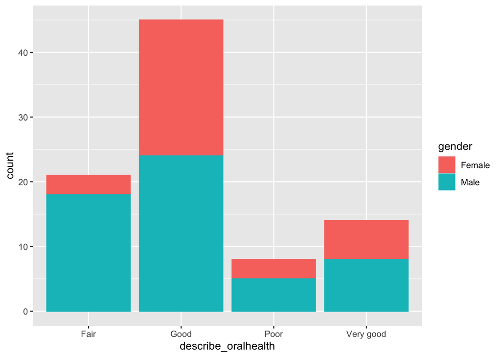

```r
ggplot(rawSelection2) + geom_bar(aes(x=describe_oralhealth, col=gender, fill=gender))
```

```r
# names(rawSelection2)
is.factor('describe_oralheath')
```

```
## [1] FALSE
```

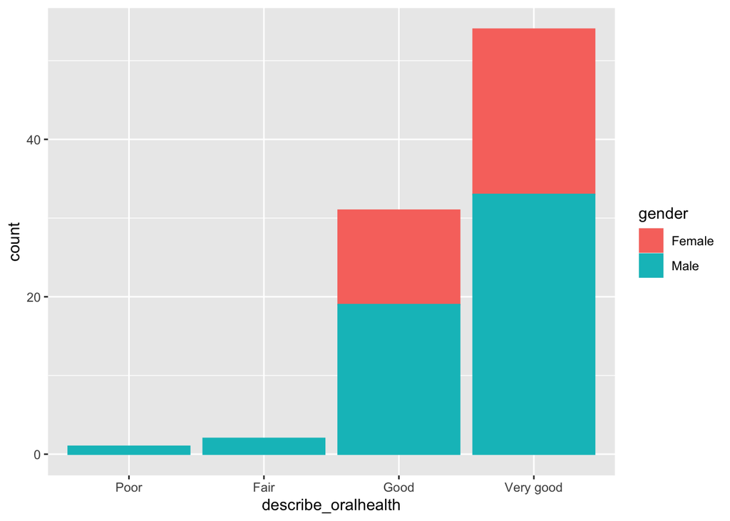

```r
p <- rawSelection2 %>%
  mutate(describe_oralhealth = as.factor(describe_health)) %>%
  mutate(describe_oralhealth = fct_relevel(describe_oralhealth,
                                           c("Poor",
                                             "Fair",
                                             "Good",
                                             "Very good")
                                           )) %>%
  ggplot() +
  geom_bar(aes(x= describe_oralhealth, col=gender, fill=gender))

p
```

```r
rawSelection2 %>% select(last_dental_visit)
```

```
## # A tibble: 88 × 1
##    last_dental_visit
##    <chr>
##  1 More than 2 years ago
##  2 Within the past 6 months
##  3 1-2 years ago
##  4 6-12 months ago
##  5 Within the past 6 months
##  6 6-12 months ago
##  7 1-2 years ago
##  8 Within the past 6 months
##  9 Within the past 6 months
## 10 6-12 months ago
## # ℹ 78 more rows
```

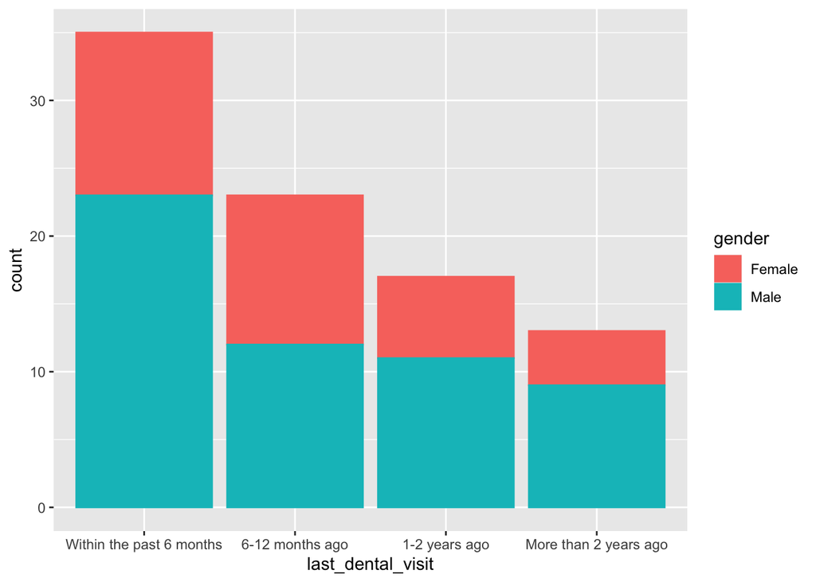

```r
p <- rawSelection2 %>%
  mutate(last_dental_visit=as_factor(last_dental_visit)) |>
  mutate(last_dental_visit=fct_relevel(last_dental_visit,
                                       c("Within the past 6 months",
                                         "6-12 months ago",
                                         "1-2 years ago",
                                         "More than 2 years ago")
                                       )) |>
  ggplot() +
  geom_bar(aes(x=last_dental_visit, col=gender, fill=gender))

p
```

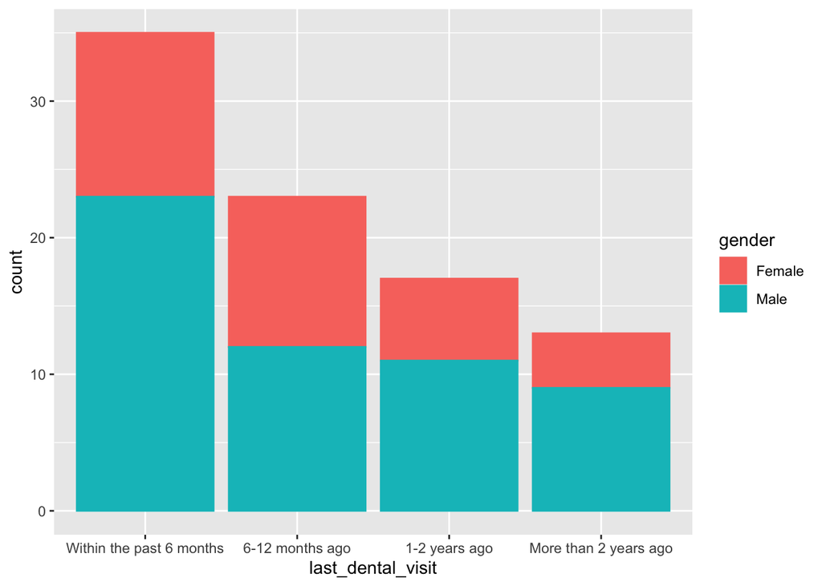

```r
p <- rawSelection2 %>%
  mutate(last_dental_visit=as_factor(last_dental_visit)) |>
  mutate(last_dental_visit=fct_relevel(last_dental_visit,
                                       c("Within the past 6 months",
                                         "6-12 months ago",
                                         "1-2 years ago",
                                         "More than 2 years ago")
                                       )) |>
  ggplot() +
  geom_bar(aes(x=last_dental_visit, col=gender, fill=gender))

p
```

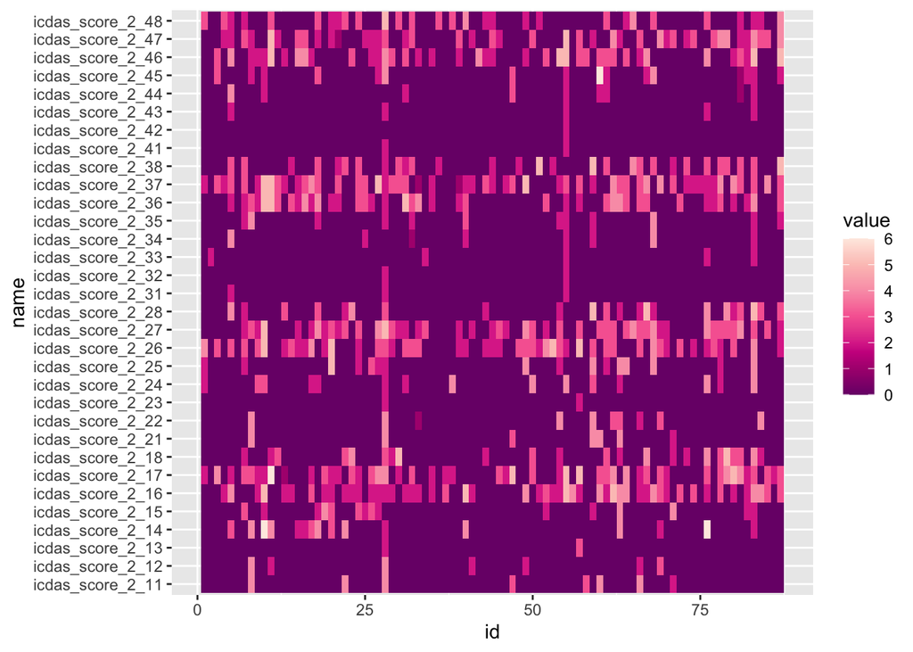

```r
icdasScore <- rawSelection2 %>% select(starts_with("icdas_score_2"), "participant_id") %>% filter(! is.na(participant_id)) %>%
  pivot_longer(cols = starts_with("icdas_sco"))

icdasScore$id <-as.numeric(as.factor(icdasScore$participant_id))
icdasScore$score_id <-as.numeric(as.factor(icdasScore$name))


ggplot(icdasScore, aes(x=id, y=name, fill=value)) + geom_tile() +   scale_fill_distiller(palette = "RdPu")
```

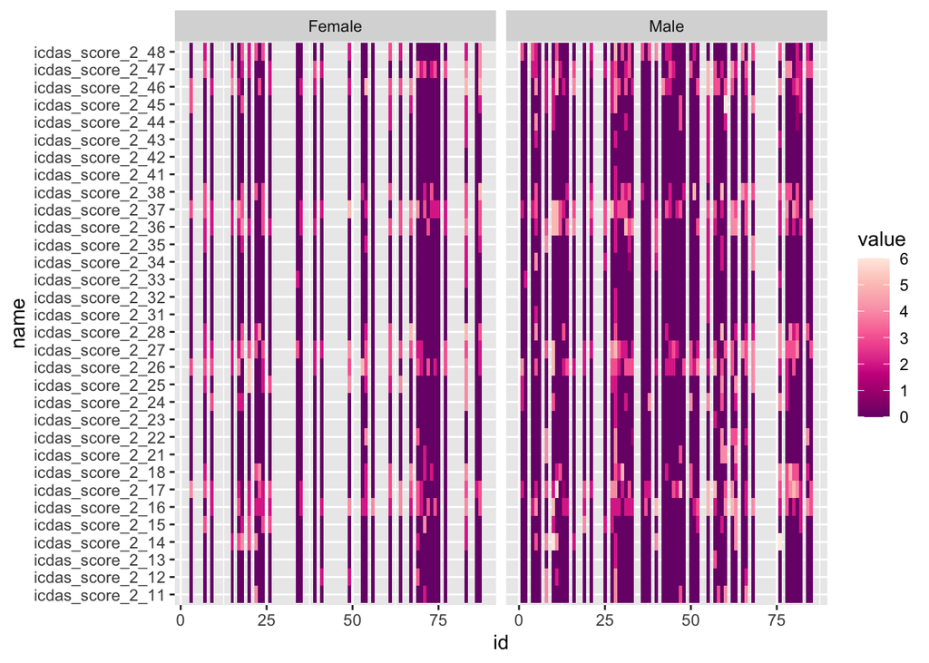

```r
icdasScoreGender <- rawSelection2 %>% select(starts_with("icdas_score_2"), "participant_id", gender) %>% filter(! is.na(participant_id)) %>%
  pivot_longer(cols = starts_with("icdas_sco"))

icdasScoreGender$id <-as.numeric(as.factor(icdasScoreGender$participant_id))
icdasScoreGender$score_id <-as.numeric(as.factor(icdasScoreGender$name))


ggplot(icdasScoreGender, aes(x=id, y=name, fill=value)) + geom_tile() +   scale_fill_distiller(palette = "RdPu") +
facet_wrap(gender~.,scales="free_x", ncol = 2)
```

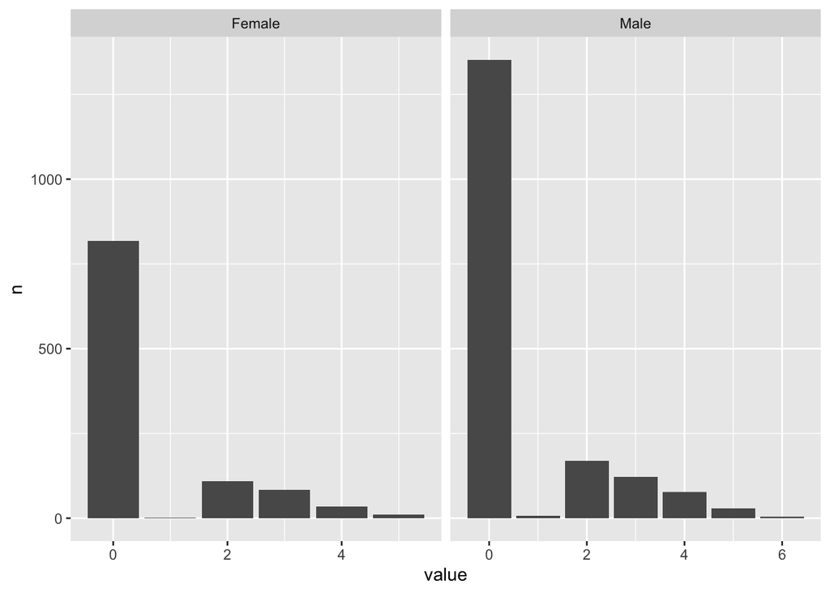

```r
icdasScore2 <- rawSelection2 %>% select(starts_with("icdas_score_2"), "participant_id", gender) %>% filter(! is.na(participant_id)) %>% filter(! is.na(participant_id)) %>%
  pivot_longer(cols = starts_with("icdas_sco")) %>%
  group_by(participant_id, gender, value) %>%
  count()

# todo cross check the geom_bar
ggplot(icdasScore2) + geom_bar(aes(x=value, y=n), stat = "identity") +
facet_wrap(gender~.,scales="free_x", ncol = 2)
```

```r
icdasScore2 %>% group_by(gender, value) %>% summarise(n=sum(n), distinct_subject=n_distinct(participant_id))
```

```
## # A tibble: 13 × 4
## # Groups:   gender [2]
##    gender value     n distinct_subject
##    <chr>  <dbl> <int>            <int>
##  1 Female     0   817               33
##  2 Female     1     1                1
##  3 Female     2   110               30
##  4 Female     3    84               26
##  5 Female     4    34               15
##  6 Female     5    10                7
##  7 Male       0  1352               54
##  8 Male       1     7                5
##  9 Male       2   169               45
## 10 Male       3   122               47
## 11 Male       4    77               30
## 12 Male       5    29               16
## 13 Male       6     4                4
```

```r
cumulativeIcdas2 <- icdasScore2 %>% group_by(value) %>% summarise(n=sum(n)) %>% mutate(csum=cumsum(n)/sum(n)*100, pc=n/sum(n)*100)

knitr::kable(cumulativeIcdas2)
```

| value | n | csum | pc |
| --- | --- | --- | --- |
| 0 | 2169 | 77.02415 | 77.0241477 |
| 1 | 8 | 77.30824 | 0.2840909 |
| 2 | 279 | 87.21591 | 9.9076705 |
| 3 | 206 | 94.53125 | 7.3153409 |
| 4 | 111 | 98.47301 | 3.9417614 |
| 5 | 39 | 99.85795 | 1.3849432 |
| 6 | 4 | 100.00000 | 0.1420455 |

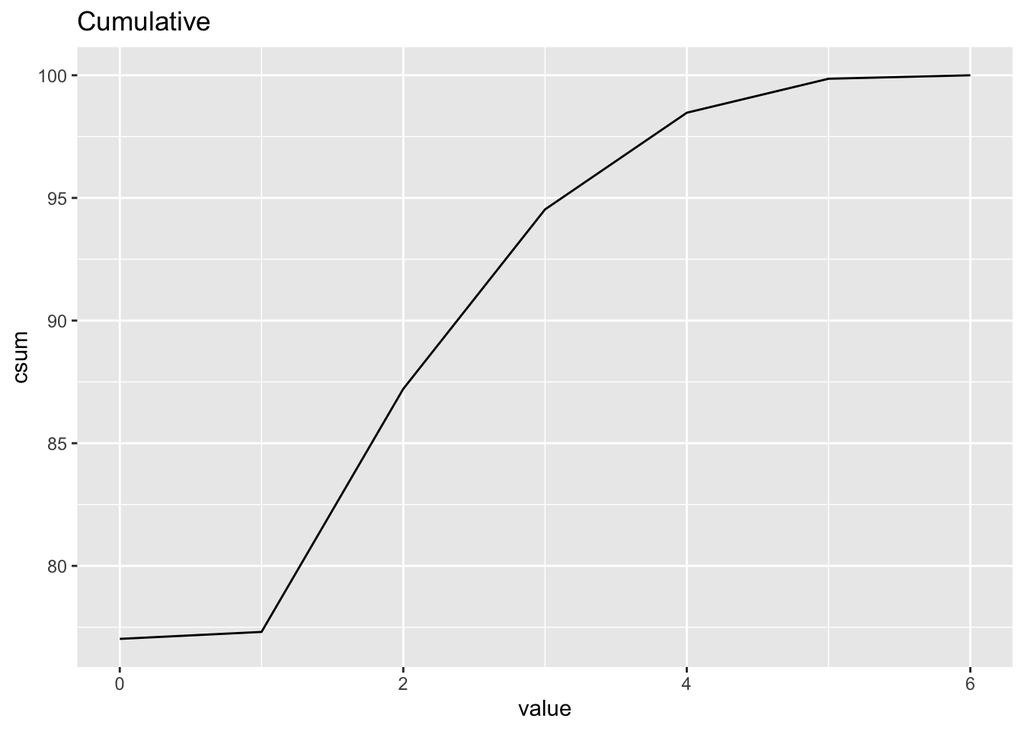

```r
ggplot(cumulativeIcdas2) + geom_line(aes(x=value, y=csum)) + ggtitle("Cumulative")
```

```r
sumCutOff <- function(value, n, cutoff){
  sum(n[value >= cutoff])
}



teethCutoff <- icdasScore2 %>% group_by(value) %>% summarise(n=sum(n)) %>%
summarise(cutoff_1=sumCutOff(value, n, 1)/sum(n)*100,
          cutoff_2=sumCutOff(value, n, 2)/sum(n)*100,
          cutoff_3=sumCutOff(value, n, 3)/sum(n)*100,
          cutoff_4=sumCutOff(value, n, 4)/sum(n)*100,
          cutoff_5=sumCutOff(value, n, 5)/sum(n)*100
          )

knitr::kable(teethCutoff)
```

| cutoff_1 | cutoff_2 | cutoff_3 | cutoff_4 | cutoff_5 |
| --- | --- | --- | --- | --- |
| 22.97585 | 22.69176 | 12.78409 | 5.46875 | 1.526989 |

```r
uniqueCutOff <- function(value, subject, cutoff){
  length(
    unique(
      subject[value >= cutoff]
    )
  )
}

participantCutoff <- tibble(
c1=uniqueCutOff(icdasScore2$value, icdasScore2$participant_id, 1),
c2=uniqueCutOff(icdasScore2$value, icdasScore2$participant_id, 2),
c3=uniqueCutOff(icdasScore2$value, icdasScore2$participant_id, 3),
c4=uniqueCutOff(icdasScore2$value, icdasScore2$participant_id, 4),
)

knitr::kable(participantCutoff)
```

| c1 | c2 | c3 | c4 |
| --- | --- | --- | --- |
| 86 | 86 | 78 | 53 |

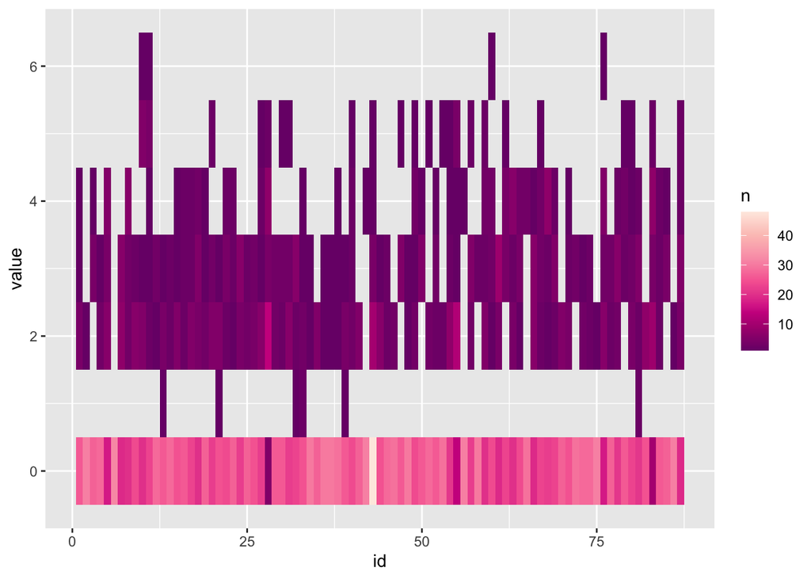

```r
idValueCount <- icdasScoreGender %>% group_by(id, value) %>% count()

ggplot(idValueCount, aes(x=id, y=value, fill=n)) + geom_tile() +   scale_fill_distiller(palette = "RdPu")
```